# Final Presentation- Group 3

2024-12-04

### Initial Setup and Libraries

```r
library(dplyr)
library(tidyverse)
```

```r
library(ggplot2)
library(corrplot)
library(quantmod)
library(PerformanceAnalytics)
library(zoo)
getwd()
```

```
## [1] "/Users/chenyien/Desktop/ECON 210A/Presentation:Project"
```

```r
msft <- read.csv("MSFT.csv")
aapl <- read.csv("AAPL.csv")
```

### Check colums in the datasets

```r
colnames(msft)
```

```
##  [1] "PERMNO"  "date"    "TICKER"  "PRC"     "VOL"     "RET"     "OPENPRC"
##  [8] "NUMTRD"  "RETX"    "vwretx"  "ewretd"  "sprtrn"
```

```r
colnames(aapl)
```

```
##  [1] "PERMNO"  "date"    "TICKER"  "PRC"     "VOL"     "RET"     "OPENPRC"
##  [8] "NUMTRD"  "RETX"    "vwretx"  "ewretd"  "sprtrn"
```

## Part 0. Cleaning

### Remove Duplicate Rows

```r
# Remove duplicate rows from the 'msft' and 'aapl' data frame
msft <- msft[!duplicated(msft), ]
aapl <- aapl[!duplicated(aapl), ]

# Identify rows that are duplicated in the 'msft' data frame
duplicated_rows_msft <- msft[duplicated(msft) | duplicated(msft, fromLast = TRUE), ]
# Print the rows in 'msft' that are duplicated
print(duplicated_rows_msft)
```

```
##  [1] PERMNO  date    TICKER  PRC     VOL     RET     OPENPRC NUMTRD  RETX
## [10] vwretx  ewretd  sprtrn
## <0 rows> (or 0-length row.names)
```

```r
# Identify rows that are duplicated in the 'aapl' data frame
duplicated_rows_aapl <- aapl[duplicated(aapl) | duplicated(aapl, fromLast = TRUE), ]
# Print the rows in 'aapl' that are duplicated
print(duplicated_rows_aapl)
```

```
##  [1] PERMNO  date    TICKER  PRC     VOL     RET     OPENPRC NUMTRD  RETX
## [10] vwretx  ewretd  sprtrn
## <0 rows> (or 0-length row.names)
```

### Handle Missing Values

```r
# Remove all rows in the 'msft' data frame that contain any missing values
colSums(is.na(msft))
```

```
##  PERMNO    date  TICKER     PRC     VOL     RET OPENPRC  NUMTRD    RETX  vwretx
##       0       0       0       0       0       0       0       0       0       0
##  ewretd  sprtrn
##       0       0
```

```r
msft <- na.omit(msft)
# Remove all rows in the 'aapl' data frame that contain any missing values
colSums(is.na(aapl))
```

```
##  PERMNO    date  TICKER     PRC     VOL     RET OPENPRC  NUMTRD    RETX  vwretx
##       0       0       0       0       0       0       0       0       0       0
##  ewretd  sprtrn
##       0       0
```

```r
aapl <- na.omit(aapl)
```

### Check Consistency

```r
# Convert the 'date' column in the 'msft' data frame to Date format
msft$date <- as.Date(msft$date, format="%Y-%m-%d")
# Sort the 'msft' data frame by the 'date' column in ascending order
msft <- msft[order(msft$date), ]

# Convert the 'date' column in the 'aapl' data frame to Date format
aapl$date <- as.Date(aapl$date, format="%Y-%m-%d")
# Sort the 'aapl' data frame by the 'date' column in ascending order
aapl <- aapl[order(aapl$date), ]
```

### Calculate Daily Returns

```r
# Calculate the daily return for the 'msft' data frame
msft <- msft %>%
  mutate(msft_daily_return = (PRC - OPENPRC) / OPENPRC)
# Calculate the daily return for the 'aapl' data frame
aapl <- aapl %>%
  mutate(aapl_daily_return = (PRC - OPENPRC) / OPENPRC)
```

*Now onto the model building.*

## Part 1. Model

### Data Analysis

#### 1) Data Visualization of Price and Return from Microsoft and Apple

```r
# Filter data for the years 2011-2015
merged_data <- msft %>%
  inner_join(aapl, by = "date", suffix = c("_msft", "_aapl"))

# Check the structure of the merged data
str(merged_data)
```

```
## 'data.frame':    2517 obs. of  25 variables:
##  $ PERMNO_msft      : int  10107 10107 10107 10107 10107 10107 10107 10107 10107 10107 ...
##  $ date             : Date, format: "2011-01-03" "2011-01-04" ...
##  $ TICKER_msft      : chr  "MSFT" "MSFT" "MSFT" "MSFT" ...
##  $ PRC_msft         : num  28 28.1 28 28.8 28.6 ...
##  $ VOL_msft         : int  53613367 54542150 59012770 88255842 73953602 57697717 50440195 52760085 67260332 62847432 ...
##  $ RET_msft         : num  0.00251 0.00384 -0.00312 0.02929 -0.00763 ...
##  $ OPENPRC_msft     : num  28.1 27.9 27.9 28 28.6 ...
##  $ NUMTRD_msft      : int  132764 129971 147754 231817 196746 143305 128620 136142 171426 149112 ...
##  $ RETX_msft        : num  0.00251 0.00384 -0.00312 0.02929 -0.00763 ...
##  $ vwretx_msft      : num  0.01118 -0.00394 0.0053 -0.00276 -0.00195 ...
##  $ ewretd_msft      : num  0.01253 -0.00675 0.00794 -0.00121 -0.00285 ...
##  $ sprtrn_msft      : num  0.01132 -0.00131 0.00501 -0.00212 -0.00185 ...
##  $ msft_daily_return: num  -0.0025 0.00528 0.00358 0.02782 -0.0014 ...
##  $ PERMNO_aapl      : int  14593 14593 14593 14593 14593 14593 14593 14593 14593 14593 ...
##  $ TICKER_aapl      : chr  "AAPL" "AAPL" "AAPL" "AAPL" ...
##  $ PRC_aapl         : num  330 331 334 334 336 ...
##  $ VOL_aapl         : int  16438280 11444072 9486655 11138250 11645048 16708869 16549770 11203833 11093597 11496157 ...
##  $ RET_aapl         : num  0.021732 0.005219 0.00818 -0.000808 0.007161 ...
##  $ OPENPRC_aapl     : num  326 332 330 335 334 ...
##  $ NUMTRD_aapl      : num  102785 75216 62265 66087 77382 ...
##  $ RETX_aapl        : num  0.021732 0.005219 0.00818 -0.000808 0.007161 ...
##  $ vwretx_aapl      : num  0.01118 -0.00394 0.0053 -0.00276 -0.00195 ...
##  $ ewretd_aapl      : num  0.01253 -0.00675 0.00794 -0.00121 -0.00285 ...
##  $ sprtrn_aapl      : num  0.01132 -0.00131 0.00501 -0.00212 -0.00185 ...
##  $ aapl_daily_return: num  0.01207 -0.00346 0.0135 -0.00295 0.00638 ...
```

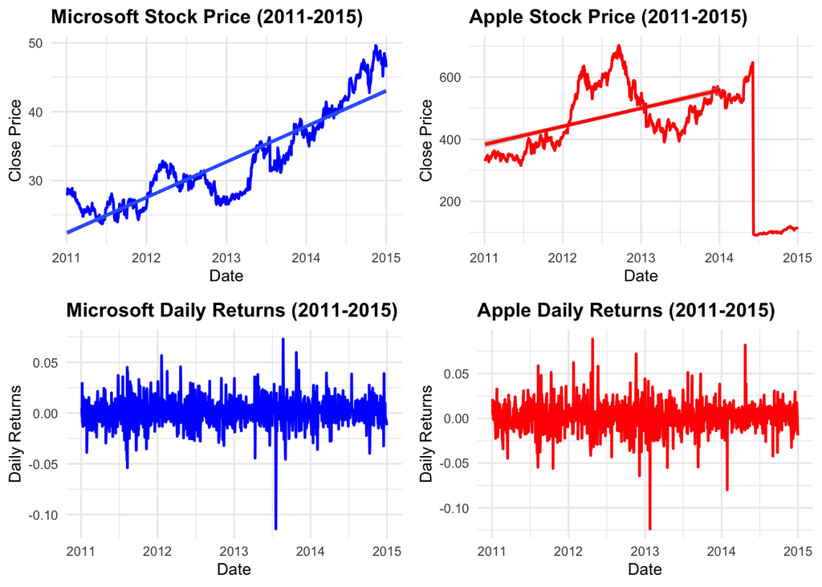

```r
training_data <- merged_data %>%
  filter(year(date) >= 2011 & year(date) < 2015)

# Create a custom theme for the plots
my_theme <- theme_minimal() +
  theme(
    plot.title = element_text(size = 12, face = "bold"),
    axis.title = element_text(size = 10),
    axis.text = element_text(size = 8)
  )

# Create four plots
p1 <- ggplot(training_data, aes(x = date, y = PRC_msft)) +
  geom_line(color = "blue", linewidth = 0.8) +
  geom_smooth(method='lm')+
  labs(title = "Microsoft Stock Price (2011-2015)",
       x = "Date",
       y = "Close Price") +
  my_theme

p2 <- ggplot(training_data, aes(x = date, y = PRC_aapl)) +
  geom_line(color = "red", linewidth = 0.8) +
   geom_smooth(data = subset(training_data, date <= as.Date("2013-12-31")),
              method = 'lm',
              color = "red",)+
  labs(title = "Apple Stock Price (2011-2015)",
       x = "Date",
       y = "Close Price") +
  my_theme

p3 <- ggplot(training_data, aes(x = date, y = RET_msft)) +
  geom_line(color = "blue", linewidth = 0.8) +
  labs(title = "Microsoft Daily Returns (2011-2015)",
       x = "Date",
       y = "Daily Returns") +
  my_theme

p4 <- ggplot(training_data, aes(x = date, y = RET_aapl)) +
  geom_line(color = "red", linewidth = 0.8) +
  labs(title = "Apple Daily Returns (2011-2015)",
       x = "Date",
       y = "Daily Returns") +
  my_theme

# Use grid.arrange to combine the four plots into a single layout
library(gridExtra)
grid.arrange(p1, p2, p3, p4, ncol = 2)
```

**Takeways:**

1. Microsoft’s stock price and returns suggest stability and consistent growth.
2. The sudden drop in Apple’s stock price (mid-2014) was due to a 1:7 stock split, not a drop in real value.

#### 2） Correlation Analysis Between Microsoft VS Apple

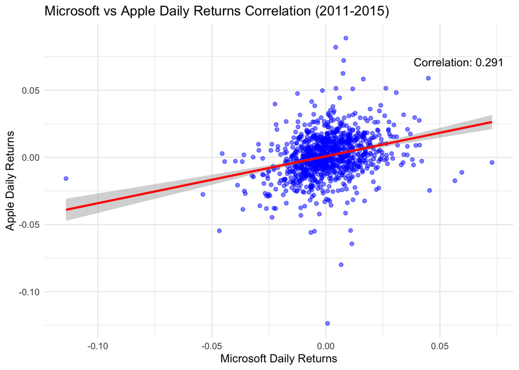

```r
# Calculate the correlation coefficient for daily returns between Microsoft and Apple (2011-2015)
correlation <- cor(training_data$RET_msft,
                  training_data$RET_aapl,
                  use = "complete.obs")

# Create a scatter plot to visualize the correlation between Microsoft and Apple daily returns
ggplot(training_data, aes(x = RET_msft, y = RET_aapl)) +
  geom_point(alpha = 0.5, color = "blue") +
  geom_smooth(method = "lm", color = "red") +
  labs(title = "Microsoft vs Apple Daily Returns Correlation (2011-2015)",
       x = "Microsoft Daily Returns",
       y = "Apple Daily Returns") +
  theme_minimal() +
  annotate("text",
           x = max(training_data$RET_msft, na.rm = TRUE) * 0.8,
           y = max(training_data$RET_aapl, na.rm = TRUE) * 0.8,
           label = paste("Correlation:", round(correlation, 3)))
```

**Takeways**：

1. A positive linear relationship between the daily returns of Microsoft and Apple from 2011 to 2015.

### Model Building

#### 1）Factor Selection and Predictive Modeling

```r
# Build an extended factor pool and select predictive factors
model_data <- training_data %>%
  filter(year(date) >= 2011 & year(date) < 2015) %>% # Filter data between 2011 and 2014
  arrange(date) %>%
  mutate(
    # 1. Define the target variable (next day's return)
    next_return = lead(RET_msft, 1),

    # 2. MSFT-specific factors
    # (2.1) Short-term momentum factors
    ret_lag1 = lag(RET_msft, 1), # Lagged 1-period return
    ret_lag2 = lag(RET_msft, 2), # Lagged 2-period return
    ret_lag3 = lag(RET_msft, 3), # Lagged 3-period return
    ret_lag5 = lag(RET_msft, 5), # Lagged 5-period return

    # (2.2) Cumulative return factors
    ret_cum3 = rollsum(lag(RET_msft), k = 3, fill = NA), # 3-period cumulative return
    ret_cum5 = rollsum(lag(RET_msft), k = 5, fill = NA), # 5-period cumulative return
    ret_cum10 = rollsum(lag(RET_msft), k = 10, fill = NA), # 10-period cumulative return

    # (2.3) Moving average ratio factors
    ma5_ratio = lag(PRC_msft/rollmean(PRC_msft, k = 5, fill = NA) - 1,1), # Ratio to 5-period moving average
    ma10_ratio = lag(PRC_msft/rollmean(PRC_msft, k = 10, fill = NA) - 1,1), # Ratio to 10-period moving average
    ma20_ratio = lag(PRC_msft/rollmean(PRC_msft, k = 20, fill = NA) - 1,1), # Ratio to 20-period moving average

    # (2.4) Volatility factors
    vol_3d = lag(rollapply(RET_msft, width = 3, FUN = sd, fill = NA),1), # 3-period volatility
    vol_5d = lag(rollapply(RET_msft, width = 5, FUN = sd, fill = NA),1), # 5-period volatility
    vol_10d = lag(rollapply(RET_msft, width = 10, FUN = sd, fill = NA),1), # 10-period volatility

     # (2.5) Volume-related factors
    vol_ratio = lag(VOL_msft/rollmean(VOL_msft, k = 20, fill = NA),1),  # Volume ratio to 20-period moving average
    vol_trend = lag(rollmean(VOL_msft, k = 5, fill = NA)/rollmean(VOL_msft, k = 20, fill = NA),1),# Volume trend factor

    # 3. Market-related factors
    market_lag1 = lag(sprtrn_msft, 1), # Lagged 1-period market return
    market_lag2 = lag(sprtrn_msft, 2), # Lagged 2-period market return
    market_cum3 = rollsum(lag(sprtrn_msft), k = 3, fill = NA), # 3-period cumulative market return

    # 4. Peer-related factors (e.g., AAPL as a peer company)
    aapl_lag1 = lag(RET_aapl, 1),
    aapl_cum3 = rollsum(lag(RET_aapl), k = 3, fill = NA)

  ) %>%
  na.omit()

# # Create a list of all factor names
factors <- c("ret_lag1", "ret_lag2", "ret_lag3", "ret_lag5",
             "ret_cum3", "ret_cum5", "ret_cum10",
             "ma5_ratio", "ma10_ratio", "ma20_ratio",
             "vol_3d", "vol_5d", "vol_10d",
             "vol_ratio", "vol_trend",
             "market_lag1", "market_lag2", "market_cum3",
             "aapl_lag1", "aapl_cum3")

# Calculate the correlation between each factor and the target variable
correlations <- cor(model_data[factors], model_data$next_return)

# Calculate the correlation matrix between factors
factor_cor_matrix <- cor(model_data[factors])

# Select significant factors based on their correlation with the target variable
significant_factors <- factors[abs(correlations) > 0.05]  # Threshold for significance is 0.05

# Filter factors to remove highly correlated ones
final_factors <- c()
correlation_threshold <- 0.5  # Threshold for inter-factor correlation

for(factor in significant_factors) {
  #Check if the current factor is highly correlated with already selected factors
  if(length(final_factors) == 0) {
    final_factors <- c(final_factors, factor) # Add the first factor
  } else {
    correlations_with_selected <- abs(factor_cor_matrix[factor, final_factors])
    if(all(correlations_with_selected < correlation_threshold)) {
      final_factors <- c(final_factors, factor) # Add factor if correlations are below the threshold
    }
  }
}

# Build the final regression formula
formula <- as.formula(paste("next_return ~", paste(final_factors, collapse = " + ")))

# Fit the linear regression model using the selected factors
final_model <- lm(formula, data = model_data)

# Display the summary of the regression model
summary(final_model)
```

```
##
## Call:
## lm(formula = formula, data = model_data)
##
## Residuals:
##       Min        1Q    Median        3Q       Max
## -0.076940 -0.006800 -0.000255  0.006702  0.062469
##
## Coefficients:
##              Estimate Std. Error t value Pr(>|t|)
## (Intercept)  0.001974   0.002011   0.982    0.327
## ret_cum5     0.207197   0.012741  16.262  < 2e-16 ***
## ma5_ratio   -0.507730   0.042027 -12.081  < 2e-16 ***
## vol_trend   -0.001840   0.001975  -0.932    0.352
## aapl_cum3   -0.058293   0.012945  -4.503  7.5e-06 ***
## ---
## Signif. codes:  0 '***' 0.001 '**' 0.01 '*' 0.05 '.' 0.1 ' ' 1
##
## Residual standard error: 0.01174 on 982 degrees of freedom
## Multiple R-squared:  0.3005, Adjusted R-squared:  0.2976
## F-statistic: 105.5 on 4 and 982 DF,  p-value: < 2.2e-16
```

**Takeways**：

1. Significant Predictors:

   ret_cum5 (5-period cumulative return)

   ma5_ratio (5-period moving average ratio)

   aapl_cum3 (3-period cumulative return of AAPL)
2. Non-Significant Predictors:

   vol_trend (volume trend)
3. The moderate R-squared suggests that additional factors might improve the model’s explanatory power.

#### 2）Final Model Building

```r
# Build predictive factors and construct the regression model
model_data <- training_data %>%
  filter(year(date) >= 2011 & year(date) < 2015) %>%
  arrange(date) %>%
  mutate(
    # Define the target variable: next day's return
    next_return = lead(RET_msft, 1),

    # 5-period cumulative return factor for MSFT
    ret_cum5 = rollsum(lag(RET_msft), k = 5, fill = NA),

    # Ratio of the stock price to its 5-day moving average
    ma5_ratio = lag(PRC_msft/rollmean(PRC_msft, k = 5, fill = NA) - 1,1),

    # 3-period cumulative return factor for AAPL (peer company)
    aapl_cum3 = rollsum(lag(RET_aapl), k = 3, fill = NA)

  ) %>%
  na.omit()

# Build the final linear regression model
final_model <- lm(next_return ~  ret_cum5 +
                  ma5_ratio + aapl_cum3,
                  data = model_data)
```

#### 3）Model Forecasting and Evaluation on Testing Data

```r
# Read and prepare the dataset
# data <- read.csv("MSFT.csv")

# Convert the date column to Date format
# data$date <- as.Date(data$date)

# Split the data into training and testing sets
training_data <- merged_data %>%
  filter(year(date) >= 2011 & year(date) < 2015) # Training data: 2011–2014

testing_data <- merged_data %>%
  filter(year(date) >= 2015 & year(date) < 2016) # Testing data: 2015

# Prepare the testing dataset for forecasting
forecast_data <- testing_data %>%
  arrange(date) %>%
  mutate(
    next_return = lead(RET_msft, 1),
    ret_cum5 = rollsum(lag(RET_msft), k = 5, fill = NA),
    ma5_ratio = lag(PRC_msft/rollmean(PRC_msft, k = 5, fill = NA) - 1,1),
    aapl_cum3 = rollsum(lag(RET_aapl), k = 3, fill = NA)
  ) %>%
  na.omit()

# Generate predictions using the trained model
forecast_data$predicted_return <- predict(final_model, newdata = forecast_data)
forecast_data$error <- forecast_data$next_return - forecast_data$predicted_return

# Analyze prediction errors
error_summary <- summary(forecast_data$error)
print(error_summary)
```

```
##       Min.    1st Qu.     Median       Mean    3rd Qu.       Max.
## -0.0613251 -0.0082548 -0.0005273 -0.0001463  0.0056413  0.0641457
```

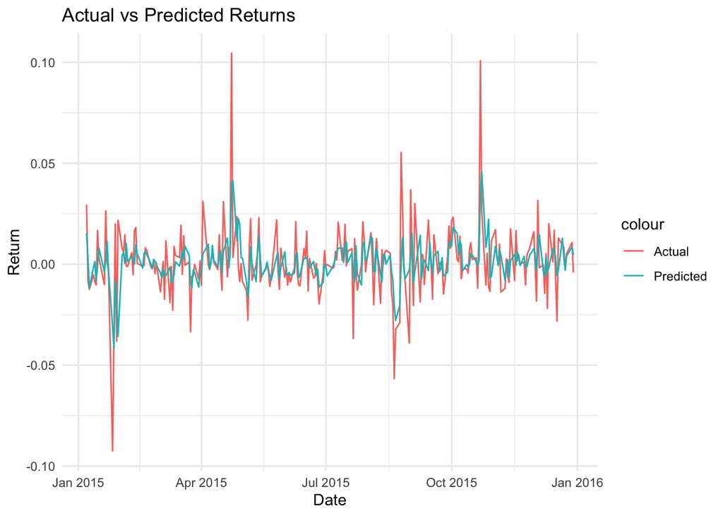

```r
# Calculate performance metrics
rmse <- sqrt(mean(forecast_data$error^2)) # Root Mean Squared Error (RMSE)
mae <- mean(abs(forecast_data$error)) # Mean Absolute Error (MAE)

# Visualize actual vs. predicted returns
ggplot(forecast_data, aes(x = date)) +
  geom_line(aes(y = next_return, color = "Actual")) +
  geom_line(aes(y = predicted_return, color = "Predicted")) +
  labs(title = "Actual vs Predicted Returns",
       x = "Date",
       y = "Return") +
  theme_minimal()
```

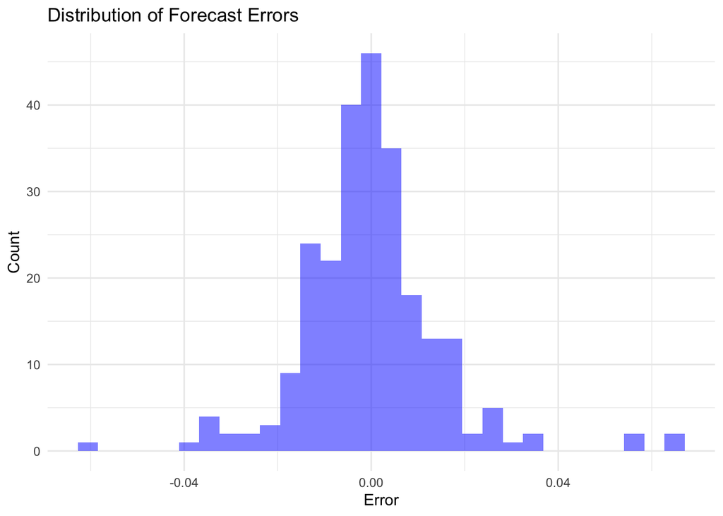

```r
# Visualize the distribution of prediction errors
ggplot(forecast_data, aes(x = error)) +
  geom_histogram(bins = 30, fill = "blue", alpha = 0.5) +
  labs(title = "Distribution of Forecast Errors",
       x = "Error",
       y = "Count") +
  theme_minimal()
```

**Takeways:**

1. The predicted returns align closely with actual returns, showing the model effectively captures the overall trend.
2. During high volatility periods, the model struggles to predict extreme spikes.
3. The majority of errors are concentrated near zero, indicating the model’s predictions are unbiased on average.

### Model Optimization

```r
# Filter the data to create a training dataset (2011–2014)
merged_data <- msft %>%
  inner_join(aapl, by = "date", suffix = c("_msft", "_aapl"))

training_data <- merged_data %>%
  filter(year(date) >= 2011 & year(date) < 2015)

# Construct an extended feature set for training
model_data_1 <- training_data %>%
  filter(year(date) >= 2011 & year(date) < 2015) %>%
  arrange(date) %>%
  mutate(
    # Define the target variable: next day's return for MSFT
    next_return = lead(RET_msft, 1),

    # 1. MSFT-specific factors
    # (1.1) Price momentum factors
    ret_lag1 = RET_msft,  # Current return
    ret_lag2 = lag(RET_msft, 1), # Lagged 1-period return
    ret_lag3 = lag(RET_msft, 2), # Lagged 2-period return
    ret_lag5 = lag(RET_msft, 4), # Lagged 4-period return

    # (1.2) Cumulative return factors
    ret_cum3 = rollsum(RET_msft, k = 3, fill = NA), # 3-period cumulative return
    ret_cum5 = rollsum(RET_msft, k = 5, fill = NA), # 5-period cumulative return
    ret_cum10 = rollsum(RET_msft, k = 10, fill = NA), # 10-period cumulative return

    # (1.3) Price trend factors
    ma5_ratio = PRC_msft/rollmean(PRC_msft, k = 5, fill = NA) - 1, # 5-day moving average ratio
    ma10_ratio = PRC_msft/rollmean(PRC_msft, k = 10, fill = NA) - 1,# 10-day moving average ratio
    ma20_ratio = PRC_msft/rollmean(PRC_msft, k = 20, fill = NA) - 1,# 20-day moving average ratio

    # (1.4) Volatility factors
    vol_3d = rollapply(RET_msft, width = 3, FUN = sd, fill = NA), # 3-day volatility
    vol_5d = rollapply(RET_msft, width = 5, FUN = sd, fill = NA), # 5-day volatility
    vol_10d = rollapply(RET_msft, width = 10, FUN = sd, fill = NA), # 10-day volatility

     # (1.5) Volume factors
    vol_ratio = VOL_msft/rollmean(VOL_msft, k = 20, fill = NA),  # Volume ratio to 20-day moving average
    vol_trend = rollmean(VOL_msft, k = 5, fill = NA)/rollmean(VOL_msft, k = 20, fill = NA), # Volume trend ratio

    #2. Market-related factors
    market_lag1 = sprtrn_msft, # Current market return
    market_lag2 = lag(sprtrn_msft, 1), # Lagged 1-period market return
    market_cum3 = rollsum(sprtrn_msft, k = 3, fill = NA), # 3-period cumulative market return

    ## 3. Peer company factors (AAPL)
    aapl_lag1 = RET_aapl, # Current return for AAPL
    aapl_cum3 = rollsum(RET_aapl, k = 3, fill = NA) # 3-period cumulative return for AAPL

  ) %>%
  na.omit()

# Create a list of all feature names
factors <- c("ret_lag1", "ret_lag2", "ret_lag3", "ret_lag5",
             "ret_cum3", "ret_cum5", "ret_cum10",
             "ma5_ratio", "ma10_ratio", "ma20_ratio",
             "vol_3d", "vol_5d", "vol_10d",
             "vol_ratio", "vol_trend",
             "market_lag1", "market_lag2", "market_cum3",
             "aapl_lag1", "aapl_cum3")

# Calculate the correlation between features and the target variable
correlations <- cor(model_data_1[factors], model_data_1$next_return)

# Calculate the correlation matrix between features
factor_cor_matrix <- cor(model_data_1[factors])

# Select significant factors based on their correlation with the target variable
significant_factors <- factors[abs(correlations) > 0.05]  # Threshold for correlation significance

# Further refine the factors by removing highly correlated ones
final_factors <- c()
correlation_threshold <- 0.5

for(factor in significant_factors) {
 # Check if the current factor is highly correlated with any already selected factors
  if(length(final_factors) == 0) {
    final_factors <- c(final_factors, factor)
  } else {
    correlations_with_selected <- abs(factor_cor_matrix[factor, final_factors])
    if(all(correlations_with_selected < correlation_threshold)) {
      final_factors <- c(final_factors, factor)
    }
  }
}
# Construct the final linear regression model using the selected factors
formula <- as.formula(paste("next_return ~", paste(final_factors, collapse = " + ")))
final_model_1 <- lm(formula, data = model_data_1)

# View the summary of the final model
summary(final_model_1)
```

```
##
## Call:
## lm(formula = formula, data = model_data_1)
##
## Residuals:
##        Min         1Q     Median         3Q        Max
## -0.0167556 -0.0025433  0.0001123  0.0026540  0.0234909
##
## Coefficients:
##               Estimate Std. Error t value Pr(>|t|)
## (Intercept)  0.0006636  0.0003933   1.687   0.0918 .
## ret_cum3     0.4451198  0.0067422  66.020   <2e-16 ***
## ret_cum10   -0.0344578  0.0041017  -8.401   <2e-16 ***
## ma5_ratio   -1.2171461  0.0162368 -74.962   <2e-16 ***
## vol_ratio   -0.0007175  0.0003666  -1.957   0.0506 .
## aapl_lag1    0.0123782  0.0085327   1.451   0.1472
## ---
## Signif. codes:  0 '***' 0.001 '**' 0.01 '*' 0.05 '.' 0.1 ' ' 1
##
## Residual standard error: 0.004343 on 981 degrees of freedom
## Multiple R-squared:  0.9037, Adjusted R-squared:  0.9032
## F-statistic:  1842 on 5 and 981 DF,  p-value: < 2.2e-16
```

**Takeways:**

1.The model explains approximately 90.37% of the variance in the target variable,indicating excellent fit to the data.

2.Key Predictors:

```
ret_cum3: cumulative returns (3 periods)

ret_cum10: cumulative returns (10 periods)

ma5_ratio: the 5-day moving average.
```

```r
# Build predictive factors for the training dataset
model_data_1 <- training_data %>%
  filter(year(date) >= 2011 & year(date) < 2015) %>%
  arrange(date) %>%
  mutate(
    next_return = lead(RET_msft, 1),

    # Cumulative returns
    ret_cum3 = rollsum(RET_msft, k = 3, fill = NA),
    ret_cum10 = rollsum(RET_msft, k = 10, fill = NA),

    # Moving average ratio
    ma5_ratio = PRC_msft/rollmean(PRC_msft, k = 5, fill = NA) - 1

  ) %>%
  na.omit()

# Build the final linear regression model
final_model_1 <- lm(next_return ~  ret_cum3 + ret_cum10+
                  ma5_ratio,
                  data = model_data_1)
```

```r
# Load the original dataset (assumes the data is stored in MSFT.csv)
# data <- read.csv("MSFT.csv")

# Convert the date column to Date format
# data$date <- as.Date(data$date)

# Split the dataset into training and testing sets
training_data <- merged_data %>%
  filter(year(date) >= 2011 & year(date) < 2015)  # Training data: 2011–2014

testing_data <- merged_data %>%
  filter(year(date) >= 2015 & year(date) < 2016)  # Testing data: 2015

# Prepare the testing dataset for forecasting
forecast_data_1 <- testing_data %>%
  arrange(date) %>%  # Sort data by date
  mutate(
    # Define the target variable: next day's return
    next_return = lead(RET_msft, 1),

    # Cumulative returns
    ret_cum3 = rollsum(RET_msft, k = 3, fill = NA),  # 3-period cumulative return
    ret_cum10 = rollsum(RET_msft, k = 10, fill = NA),  # 10-period cumulative return

    # Moving average ratio
    ma5_ratio = PRC_msft / rollmean(PRC_msft, k = 5, fill = NA) - 1  # 5-day moving average ratio
  ) %>%
  na.omit()

# Generate predictions using the final model
forecast_data_1$predicted_return <- predict(final_model_1, newdata = forecast_data_1)

# Calculate prediction errors
forecast_data_1$error <- forecast_data_1$next_return - forecast_data_1$predicted_return

# Analyze prediction errors
error_summary <- summary(forecast_data_1$error)
print(error_summary)
```

```
##       Min.    1st Qu.     Median       Mean    3rd Qu.       Max.
## -1.926e-02 -2.805e-03  4.109e-04 -4.475e-05  3.203e-03  2.304e-02
```

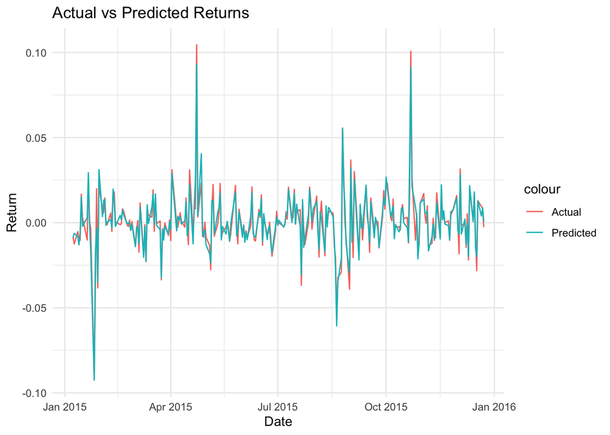

```r
# Calculate performance metrics
rmse <- sqrt(mean(forecast_data_1$error^2))  # Root Mean Squared Error (RMSE)
mae <- mean(abs(forecast_data_1$error))  # Mean Absolute Error (MAE)

# Visualize actual vs predicted returns
ggplot(forecast_data_1, aes(x = date)) +
  geom_line(aes(y = next_return, color = "Actual")) +
  geom_line(aes(y = predicted_return, color = "Predicted")) +
  labs(title = "Actual vs Predicted Returns",
       x = "Date",
       y = "Return") +
  theme_minimal()
```

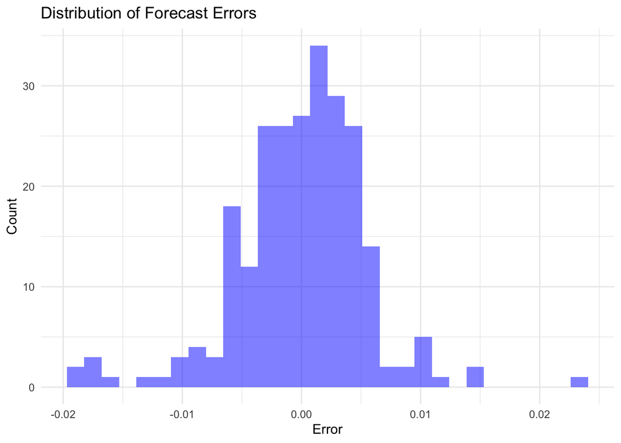

```r
# Visualize the distribution of forecast errors
ggplot(forecast_data_1, aes(x = error)) +
  geom_histogram(bins = 30, fill = "blue", alpha = 0.5) +
  labs(title = "Distribution of Forecast Errors",
       x = "Error",
       y = "Count") +
  theme_minimal()
```

**Takeways：**

1. The predicted returns closely follow the trend of actual returns.
2. The majority of forecast errors are concentrated near zero, indicating that the model’s predictions are generally unbiased and accurate.

## Part 2. Trading Strategy

### Data Preparation

Load the data and prepare the training and test datasets.

```r
# Split data into training (2011–2015) and testing (2016–2020) periods
training_data <- merged_data %>% filter(year(date) >= 2011 & year(date) < 2016)
testing_data <- merged_data %>% filter(year(date) >= 2016 & year(date) <= 2020)
```

### Forecasting Returns

Predict MSFT returns for the test period (2016-2020).

```r
# Prepare testing data with required features
forecast_data <- testing_data %>%
  arrange(date) %>%
  mutate(
    next_return = lead(RET_msft, 1),                     # target variable
    ret_cum5 = rollsum(lag(RET_msft), k = 5, fill = NA), # factor 1
    ma5_ratio = lag(PRC_msft / rollmean(PRC_msft, k = 5, fill = NA) - 1, 1), # factor 2
    aapl_cum3 = rollsum(lag(RET_aapl), k = 3, fill = NA) # factor 3
  ) %>%
  na.omit()

# Generate predictions
forecast_data$predicted_return <- predict(final_model, newdata = forecast_data)
forecast_data$error <- forecast_data$next_return - forecast_data$predicted_return

error_summary <- summary(forecast_data$error)
print(error_summary)
```

```
##       Min.    1st Qu.     Median       Mean    3rd Qu.       Max.
## -0.1676226 -0.0068175 -0.0001725  0.0001184  0.0069022  0.1413352
```

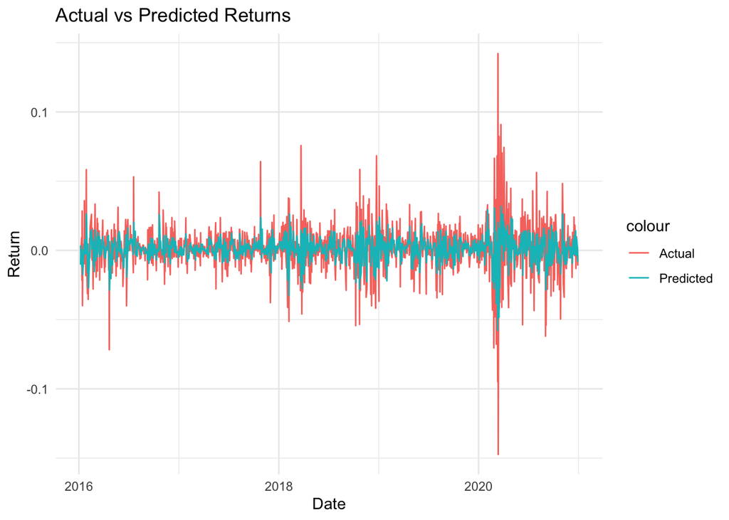

```r
rmse_msft <- sqrt(mean(forecast_data$error^2))
mae_msft <- mean(abs(forecast_data$error))

ggplot(forecast_data, aes(x = date)) +
  geom_line(aes(y = next_return, color = "Actual")) +
  geom_line(aes(y = predicted_return, color = "Predicted")) +
  labs(title = "Actual vs Predicted Returns",
       x = "Date",
       y = "Return") +
  theme_minimal()
```

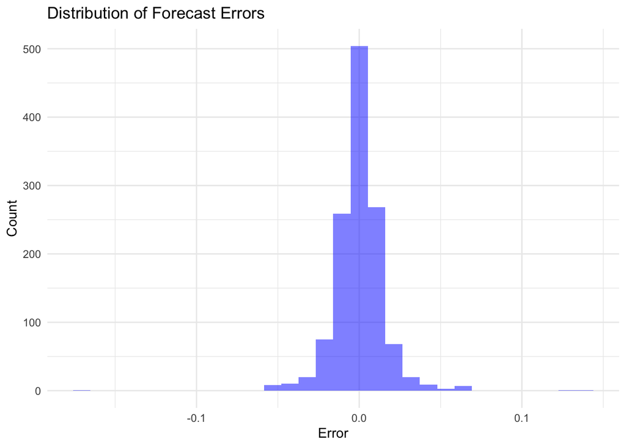

```r
ggplot(forecast_data, aes(x = error)) +
  geom_histogram(bins = 30, fill = "blue", alpha = 0.5) +
  labs(title = "Distribution of Forecast Errors",
       x = "Error",
       y = "Count") +
  theme_minimal()
```

**Takeways：**

1.The predicted returns closely follow the actual returns over most periods.

2.Significant deviations occur during periods of high volatility, such as in early 2020, likely due to market disruptions (e.g., COVID-19 pandemic).

3.The majority of forecast errors are tightly clustered around zero, suggesting that the model’s predictions are generally unbiased.

### Trading Strategy

Evaluate the trading strategies based on the forecast returns.

```r
# Implement trading strategy based on predicted returns
forecast_data <- forecast_data %>%
  arrange(date) %>%  # Sort the data by date
  mutate(
    # Position adjustment logic based on predicted returns
    position = case_when(
      predicted_return < -0.025 ~ 0,    # No position if predicted return < -2.5%
      predicted_return >= -0.025 & predicted_return < -0.015 ~ 0.25, # 25% position for -2.5% ≤ return < -1.5%
      predicted_return >= -0.015 & predicted_return < 0 ~ 0.5, # 50% position for -1.5% ≤ return < 0%
      predicted_return >= 0 ~ 1  # Full position if predicted return ≥ 0%
    ),

    # Daily returns based on the strategy
    strategy_return = RET_msft * position,

    # Cumulative returns for the strategy
    strategy_cumulative_return = cumprod(1 + strategy_return) - 1,

    # Cumulative returns for the S&P 500 index
    sp500_cumulative_return = cumprod(1 + sprtrn_msft) - 1,

    # Cumulative returns for Microsoft stock
    msft_cumulative_return = cumprod(1 + RET_msft) - 1
  )

# Output the final accumulated returns
cat("Accumulated Returns:\n")
```

```
## Accumulated Returns:
```

```r
cat("  Strategy: ", last(forecast_data$strategy_cumulative_return), "\n")  # Strategy cumulative return
```

```
##   Strategy:  49.84413
```

```r
cat("  S&P 500: ", last(forecast_data$sp500_cumulative_return), "\n")  # S&P 500 cumulative return
```

```
##   S&P 500:  0.8726455
```

```r
cat("  Microsoft: ", last(forecast_data$msft_cumulative_return), "\n\n")  # Microsoft cumulative return
```

```
##   Microsoft:  3.544193
```

**Takeway：**

1. The trading strategy achieved an accumulated return of 49.84, significantly outperforming both the S&P 500 index and Microsoft stock during the same period.
2. However, further testing and risk assessment are necessary.

### Bet Sizing

```r
forecast_data <- forecast_data %>%
  mutate(
    # Scaling factor based on strategy_cumulative_return performance
    scaling_factor = ifelse(
      strategy_cumulative_return > 0,
      1 + 0.01 * strategy_cumulative_return,  # Increase position size for positive performance
      1 - 0.01 * abs(strategy_cumulative_return)  # Slightly reduce position size for negative performance
    ),

    # Adjust daily returns using the scaling factor
    scaled_daily_return = strategy_return * scaling_factor,

    # Calculate the peak cumulative return for drawdown calculation
    peak_strategy_cumulative_return = cummax(strategy_cumulative_return),

    # Compute the drawdown (difference between peak and current cumulative return)
    drawdown = peak_strategy_cumulative_return - strategy_cumulative_return,

    # Apply drawdown control: reduce exposure by 10% if drawdown exceeds 20%
    scaled_daily_return = ifelse(drawdown > 0.2, scaled_daily_return * 0.9, scaled_daily_return),

    # Recalculate cumulative returns using the scaled daily returns
    scaled_strategy_cumulative_return = cumprod(1 + scaled_daily_return) - 1
  )

# Display the final cumulative return after applying scaling
cat("Scaled Cumulative Returns:\n")
```

```
## Scaled Cumulative Returns:
```

```r
cat("Strategy with Scaling: ", last(forecast_data$scaled_strategy_cumulative_return), "\n")
```

```
## Strategy with Scaling:  89.97668
```

**Takeways：**

1. The strategy with scaling achieved a scaled cumulative return of 89.98, showing a significant improvement compared to the unscaled strategy.

## Part 3. Performance Evaluation

### Performance Metrics

```r
# Annualized Sharpe Ratio
annualized_mean_return <- mean(forecast_data$strategy_return, na.rm = TRUE) * 252
annualized_std_dev <- sd(forecast_data$strategy_return, na.rm = TRUE) * sqrt(252)
annualized_sharpe_ratio <- annualized_mean_return / annualized_std_dev

# Information Ratio
excess_return <- forecast_data$strategy_return - forecast_data$sprtrn_msft
annualized_mean_excess_return <- mean(excess_return, na.rm = TRUE) * 252
annualized_std_dev_excess <- sd(excess_return, na.rm = TRUE) * sqrt(252)
annualized_information_ratio <- annualized_mean_excess_return / annualized_std_dev_excess

cat("Annualized Sharpe Ratio:", round(annualized_sharpe_ratio, 2), "\n")
```

```
## Annualized Sharpe Ratio: 3.69
```

```r
cat("Annualized Information Ratio:", round(annualized_information_ratio, 2), "\n")
```

```
## Annualized Information Ratio: 4.47
```

**Takeways：**

1.High Sharpe Ratio (3.69): It demonstrates the strategy’s ability to generate high returns relative to its volatility

2.Exceptional Information Ratio (4.47): It reflects the strategy’s strong ability to generate returns above the benchmark (e.g., S&P 500)

3.Both ratios suggest that the strategy not only produces high returns but also effectively manages risk.

### Compare Cumulative Returns

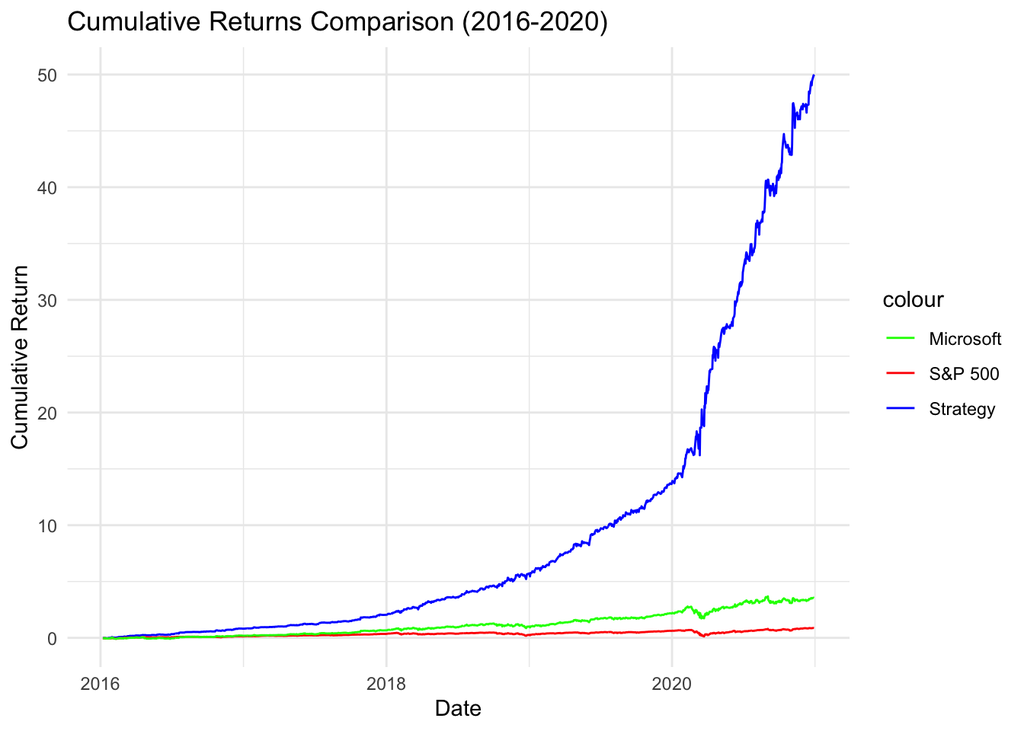

```r
# Plot cumulative returns
library(ggplot2)
ggplot(forecast_data, aes(x = date)) +
  geom_line(aes(y = strategy_cumulative_return, color = "Strategy")) +
  geom_line(aes(y = sp500_cumulative_return, color = "S&P 500")) +
  geom_line(aes(y = msft_cumulative_return, color = "Microsoft")) +
  labs(title = "Cumulative Returns Comparison (2016-2020)",
       x = "Date",
       y = "Cumulative Return") +
  theme_minimal() +
  scale_color_manual(values = c("Strategy" = "blue", "S&P 500" = "red", "Microsoft" = "green"))
```

**Takeways:**

1.The strategy (blue line) shows exponential growth in cumulative returns, reaching nearly 50 by 2020, far surpassing both Microsoft stock (green line) and the S&P 500 index (red line).